# First steps with the mipplot package

U-Tokyo mipplot team

2019-08-27

## 概要

`mipplot` パッケージは IAMC template format のデータを可視化するための `R` パッケージです。

この vignette では `mipplot` パッケージの基本機能を紹介します。

## 利用するデータ

この vignette では SR1.5 データのサブセットを使用します。 このデータは `mipplot` パッケージに含まれており、別途ダウンロードする必要はありません。

## load library

`mipplot` パッケージと `tidyverse`パッケージを読み込みます。

```r
library(mipplot)
library(tidyverse)
```

## load sample data

`mipplot` パッケージに付属の SR1.5 のサブセット データは `mipplot::sr15_sample_data` という名前でアクセスできます。中身を見てみましょう。

```r
sr15_sample_data
```

```
#> # A tibble: 396,425 x 7
#>    model      scenario region variable              unit       period value
#>    <fct>      <fct>    <fct>  <fct>                 <fct>       <int> <dbl>
#>  1 AIM/CGE 2~ SSP1-19  World  Emissions|CO2         Mt CO2/yr    2000    NA
#>  2 AIM/CGE 2~ SSP1-19  World  Final Energy          EJ/yr        2000    NA
#>  3 AIM/CGE 2~ SSP1-19  World  Population            million      2000    NA
#>  4 AIM/CGE 2~ SSP1-19  World  Price|Carbon          US$2010/t~   2000    NA
#>  5 AIM/CGE 2~ SSP1-19  World  Primary Energy        EJ/yr        2000    NA
#>  6 AIM/CGE 2~ SSP1-19  World  Primary Energy|Bioma~ EJ/yr        2000    NA
#>  7 AIM/CGE 2~ SSP1-19  World  Primary Energy|Coal   EJ/yr        2000    NA
#>  8 AIM/CGE 2~ SSP1-19  World  Primary Energy|Fossil EJ/yr        2000    NA
#>  9 AIM/CGE 2~ SSP1-19  World  Primary Energy|Gas    EJ/yr        2000    NA
#> 10 AIM/CGE 2~ SSP1-19  World  Primary Energy|Geoth~ EJ/yr        2000    NA
#> # ... with 396,415 more rows
```

中身は `tibble` 形式のデータです。ここには `model`, `scenario`, `region`, `variable`, `unit`, `period`, `value` というデータが保存されています。

なお、ファイルから別のデータを読み込むには、以下のようにします。

```r
iamc_data <- mipplot_read_iamc("path_to_data.csv")
```

データに含まれるモデルの一覧を確認しましょう。

```r
sr15_sample_data$model %>% levels
```

```
#> [1] "AIM/CGE 2.0"           "GCAM 4.2"              "IMAGE 3.0.1"
#> [4] "MESSAGE-GLOBIOM 1.0"   "MESSAGEix-GLOBIOM 1.0" "REMIND-MAgPIE 1.5"
#> [7] "WITCH-GLOBIOM 3.1"
```

シナリオの一覧を確認しましょう。

```r
sr15_sample_data$scenario %>% levels
```

```
#>  [1] "SSP1-19"         "SSP1-26"         "SSP1-34"
#>  [4] "SSP1-45"         "SSP1-Baseline"   "SSP2-19"
#>  [7] "SSP2-26"         "SSP2-34"         "SSP2-45"
#> [10] "SSP2-60"         "SSP2-Baseline"   "SSP3-34"
#> [13] "SSP3-45"         "SSP3-60"         "SSP3-Baseline"
#> [16] "SSP4-26"         "SSP4-34"         "SSP4-45"
#> [19] "SSP4-Baseline"   "SSP5-26"         "SSP5-34"
#> [22] "SSP5-45"         "SSP5-60"         "SSP5-Baseline"
#> [25] "SSP4-60"         "SSP5-19"         "LowEnergyDemand"
#> [28] "SSP4-19"
```

地域の一覧を確認しましょう。

```r
sr15_sample_data$region %>% levels
```

```
#> [1] "World"
```

変数の一覧を確認しましょう。

```r
sr15_sample_data %>% select(variable, unit) %>% distinct
```

```
#> # A tibble: 35 x 2
#>    variable                  unit
#>    <fct>                     <fct>
#>  1 Emissions|CO2             Mt CO2/yr
#>  2 Final Energy              EJ/yr
#>  3 Population                million
#>  4 Price|Carbon              US$2010/t CO2
#>  5 Primary Energy            EJ/yr
#>  6 Primary Energy|Biomass    EJ/yr
#>  7 Primary Energy|Coal       EJ/yr
#>  8 Primary Energy|Fossil     EJ/yr
#>  9 Primary Energy|Gas        EJ/yr
#> 10 Primary Energy|Geothermal EJ/yr
#> # ... with 25 more rows
```

## データのフィルタリング

`SSP2` のシナリオを含むモデルのみ抽出を例に、データのフィルタリングの方法を説明します。

```r
sr15_sample_data %>%
  filter(str_detect(scenario, "^SSP2")) %>%
  select(model, scenario) %>% distinct
```

```
#> # A tibble: 34 x 2
#>    model       scenario
#>    <fct>       <fct>
#>  1 AIM/CGE 2.0 SSP2-19
#>  2 AIM/CGE 2.0 SSP2-26
#>  3 AIM/CGE 2.0 SSP2-34
#>  4 AIM/CGE 2.0 SSP2-45
#>  5 AIM/CGE 2.0 SSP2-60
#>  6 AIM/CGE 2.0 SSP2-Baseline
#>  7 GCAM 4.2    SSP2-19
#>  8 GCAM 4.2    SSP2-26
#>  9 GCAM 4.2    SSP2-34
#> 10 GCAM 4.2    SSP2-45
#> # ... with 24 more rows
```

`str_detect` 関数に与えられている `"^SSP2"` は正規表現と呼ばれています。 `"^"` は文頭を表し、“^SSP2” という正規表現は、 “SSP2” から始まる文字列であるかをチェックするという意味になります。

`distinct` は、データの重複を除く関数です。

次に、 **Secondary Energy|Electricity|** 以下の変数の一覧を抽出してみましょう。

“|” は正規表現の中で特別な意味を持つので、これを検索するには“\|” のようにしなければなりません。これをエスケープするといいます。

```r
sr15_sample_data %>%
  filter(str_detect(variable, "^Secondary Energy\\|Electricity\\|")) %>%
  select(variable) %>%
  distinct
```

```
#> # A tibble: 10 x 1
#>    variable
#>    <fct>
#>  1 Secondary Energy|Electricity|Biomass
#>  2 Secondary Energy|Electricity|Coal
#>  3 Secondary Energy|Electricity|Gas
#>  4 Secondary Energy|Electricity|Geothermal
#>  5 Secondary Energy|Electricity|Hydro
#>  6 Secondary Energy|Electricity|Non-Biomass Renewables
#>  7 Secondary Energy|Electricity|Nuclear
#>  8 Secondary Energy|Electricity|Oil
#>  9 Secondary Energy|Electricity|Solar
#> 10 Secondary Energy|Electricity|Wind
```

## Visualization with interactive tool

`mipplot` の対話的インターフェースを使って、データのフィルタリングと可視化を行ってみましょう。

### line plot

まず line plot を行います。line plot を行うには以下のようにします。

```r
mipplot_interactive_line(sr15_sample_data)
```

すると、以下のような画面が表示されます。

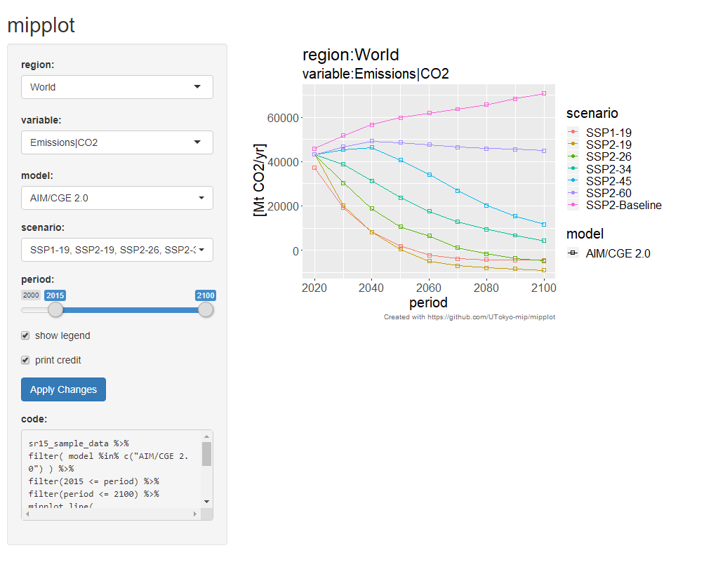

各種の条件を選択して、グラフをプロットしてください。

なお、画面にはグラフを再現するための R のコードが表示されます。 これをコピー＆ペーストすると、以下のようにプロットを編集できます。

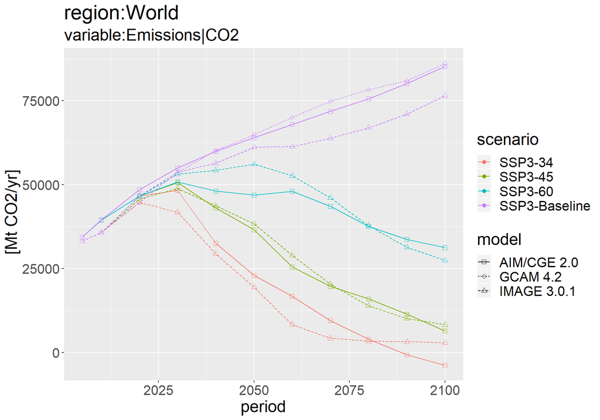

```r
data_subset <- sr15_sample_data %>%
  filter( model %in% c("AIM/CGE 2.0", "GCAM 4.2", "IMAGE 3.0.1") ) %>%
  filter(2000 <= period) %>%
  filter(period <= 2100)

mipplot_line(
  data_subset,
  variable = c("Emissions|CO2"),
  scenario = c("SSP3-34", "SSP3-45", "SSP3-60", "SSP3-Baseline"),
  region = c("World"),
  legend = TRUE,
  language = 'en')[[1]]
```

### bar plot

次に、bar plot を行います。bar plot には、ルール表が必要なため、 AR5 用のルール `ar5_db_sample_rule_table` を流用します。

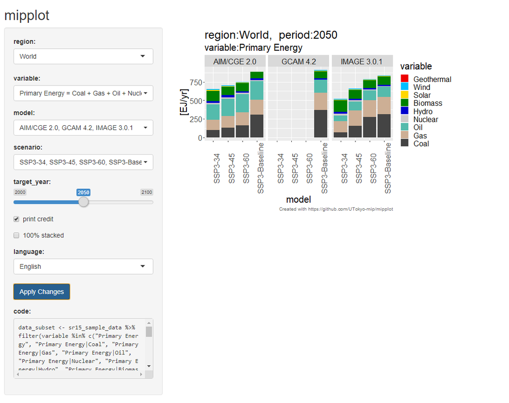

```r
mipplot_interactive_bar(sr15_sample_data, ar5_db_sample_rule_table)
```

画面にはプロットを再現するための R のコードが表示されます。 これをコピー＆ペーストすると、以下のようにプロットを編集できます。

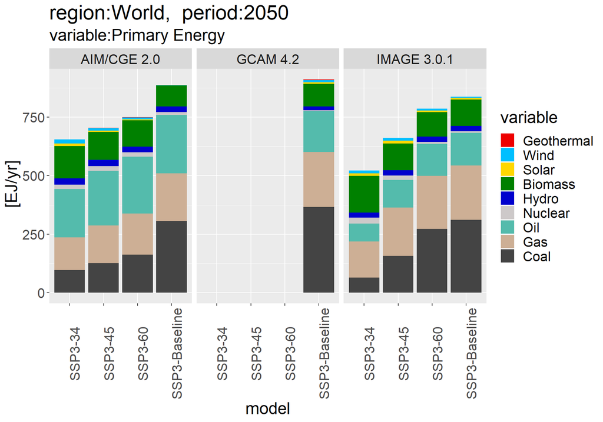

```r
data_subset <- sr15_sample_data %>%
  filter(variable %in% c("Primary Energy", "Primary Energy|Coal", "Primary Energy|Gas", "Primary Energy|Oil", "Primary Energy|Nuclear", "Primary Energy|Hydro", "Primary Energy|Biomass", "Primary Energy|Solar", "Primary Energy|Wind", "Primary Energy|Geothermal", "Primary Energy|Ocean")) %>%
  filter(model %in% c("AIM/CGE 2.0", "GCAM 4.2", "IMAGE 3.0.1")) %>%
  filter(scenario %in% c("SSP3-34", "SSP3-45", "SSP3-60", "SSP3-Baseline"))

mipplot_bar(data_subset, ar5_db_sample_rule_table,
  region = c("World"),
  target_year = 2050,
  one_hundred_percent_stacked = FALSE,
  language = 'en')[[1]]
```

### area plot

area plot を行います。area plot にもルールが必要なため、 AR5 用のルール `ar5_db_sample_rule_table` を流用します。

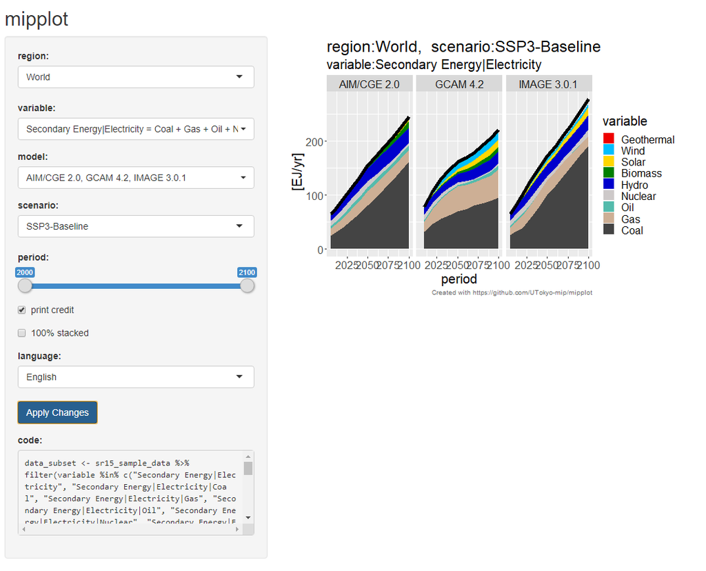

```r
mipplot_interactive_area(sr15_sample_data, ar5_db_sample_rule_table)
```

画面にはプロットを再現するための R のコードが表示されます。 これをコピー＆ペーストすると、以下のようにプロットを編集できます。

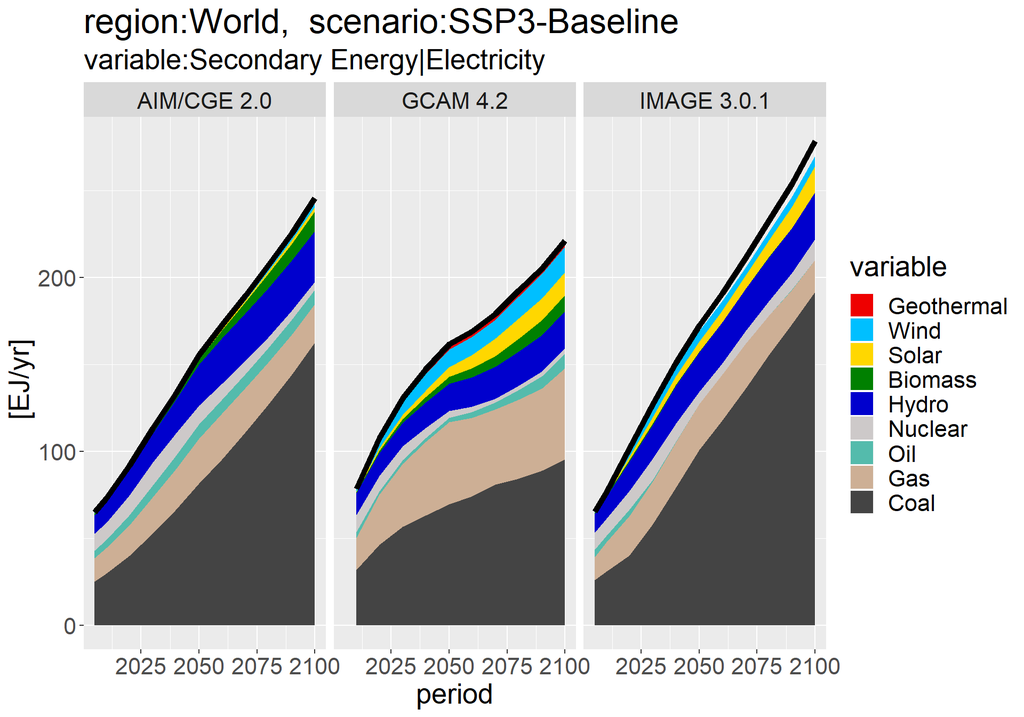

```r
data_subset <- sr15_sample_data %>%
  filter(variable %in% c("Secondary Energy|Electricity", "Secondary Energy|Electricity|Coal", "Secondary Energy|Electricity|Gas", "Secondary Energy|Electricity|Oil", "Secondary Energy|Electricity|Nuclear", "Secondary Energy|Electricity|Hydro", "Secondary Energy|Electricity|Biomass", "Secondary Energy|Electricity|Solar", "Secondary Energy|Electricity|Wind", "Secondary Energy|Electricity|Geothermal", "Secondary Energy|Electricity|Ocean")) %>%
  filter(model %in% c("AIM/CGE 2.0", "GCAM 4.2", "IMAGE 3.0.1")) %>%
  filter(2000 <= period) %>%
  filter(period <= 2100)

mipplot_area(data_subset, ar5_db_sample_rule_table,
  region = c("World"),
  scenario = c("SSP3-Baseline"),
  one_hundred_percent_stacked = FALSE,
  language = 'en')[[1]]
```

## 別の言語での出力

これまで、英語でのプロットを行ってきましたが、 これ以外にも中国語（簡体字）、中国語（繁体字）、日本語、スペイン語での プロットが可能です。

これまでのプロットでは、すべて `language = "en"` (English) と指定していたので、 これを例えば以下のように置き換えます。

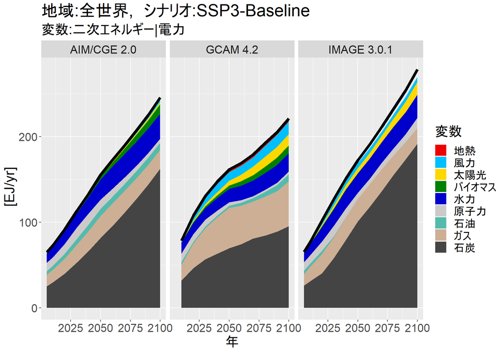

```r
data_subset <- sr15_sample_data %>%
  filter(variable %in% c("Secondary Energy|Electricity", "Secondary Energy|Electricity|Coal", "Secondary Energy|Electricity|Gas", "Secondary Energy|Electricity|Oil", "Secondary Energy|Electricity|Nuclear", "Secondary Energy|Electricity|Hydro", "Secondary Energy|Electricity|Biomass", "Secondary Energy|Electricity|Solar", "Secondary Energy|Electricity|Wind", "Secondary Energy|Electricity|Geothermal", "Secondary Energy|Electricity|Ocean")) %>%
  filter(model %in% c("AIM/CGE 2.0", "GCAM 4.2", "IMAGE 3.0.1")) %>%
  filter(2000 <= period) %>%
  filter(period <= 2100)

mipplot_area(data_subset, ar5_db_sample_rule_table,
  region = c("World"),
  scenario = c("SSP3-Baseline"),
  one_hundred_percent_stacked = FALSE,
  language = 'jp')[[1]]  # <--------------- ここを置き換えました
```

設定可能な言語と言語コードの対応表は以下の通りです。

| 言語 | 言語コード |
| --- | --- |
| 英語 | en |
| 中国語(簡体字) | zh-cn |
| 中国語(繁体字) | zh-tw |
| 日本語 | jp |
| スペイン語 | es |

## PDF ファイルへの出力

画像を PDF ファイルに出力するには、以下のようにします。

```r
data_subset <- sr15_sample_data %>%
  filter(variable %in% c("Secondary Energy|Electricity", "Secondary Energy|Electricity|Coal", "Secondary Energy|Electricity|Gas", "Secondary Energy|Electricity|Oil", "Secondary Energy|Electricity|Nuclear", "Secondary Energy|Electricity|Hydro", "Secondary Energy|Electricity|Biomass", "Secondary Energy|Electricity|Solar", "Secondary Energy|Electricity|Wind", "Secondary Energy|Electricity|Geothermal", "Secondary Energy|Electricity|Ocean")) %>%
  filter(model %in% c("AIM/CGE 2.0", "GCAM 4.2", "IMAGE 3.0.1")) %>%
  filter(2000 <= period) %>%
  filter(period <= 2100)

# グラフを変数に保存します。
graph <- mipplot_area(data_subset, ar5_db_sample_rule_table,
  region = c("World"),
  scenario = c("SSP3-Baseline"),
  one_hundred_percent_stacked = FALSE,
  language = 'zh-cn')[[1]]

# グラフを保存した変数を mipplot_print_pdf 関数に与えます。
mipplot_print_pdf(graph)
```

するとファイルを保存するダイアログが表示され、 PDF ファイルとして保存できます。